# Part II - PROSPECT LOAN DATA ANALYSIS

## Dataset Overview

This dataset consists 113,937 rows and 81 columns giving information on loans provided. The columns or features include:loan amount, borrower rate (or interest rate), current loan status, borrower income, and many other features relating to loans. The dataset information can be found [Dataset information](https://docs.google.com/spreadsheets/d/1gDyi_L4UvIrLTEC6Wri5nbaMmkGmLQBk-Yx3z0XDEtI/edit#gid=0)

## Cleaning the data.

- This involved selecting the features to be used in the analysis
- Cleaning the columns to be for efficient analysis
- Cleaning them by converting the categorical columns into categorical datatypes and dates to datetime

## Interest rate verses income range

- The \$0 class seem to have a lower interest rate. This could be because they may be volunteers or employees working under probation. However from \\$1 to \$100,000+, the interest rate on average has a decreasing trend. This could be because the higher the salary the higher the chance for getting bigger loan amounts which we realised attracted smaller interest rates.
- The higher the average salary/income, the higher the chance for getting huge loan amount.

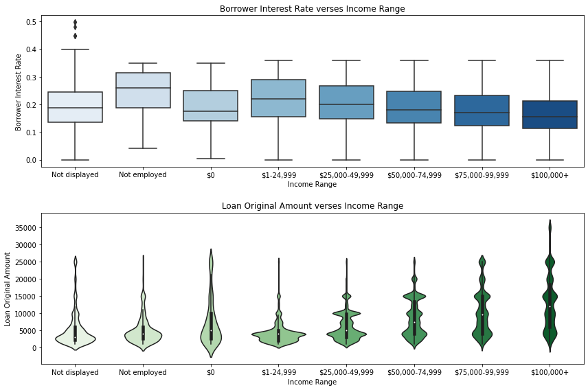

## Loan Amount verses Interest rate in comparison to the income range

It was noted that the more the amount one earns, the higher the chance of getting a huge amount of loan and hence a lower interest rate.

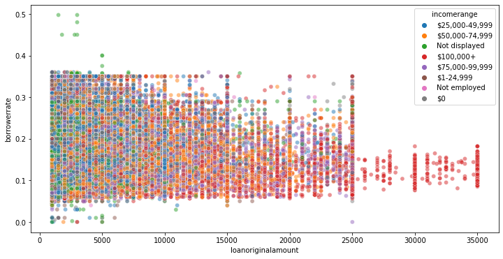

## Interest rate verses Investors with respect to loan status and employment status

It appears that as the number of investors increase, the interest rate goes down. It is also clear that very few people who are employed full time have their loan status past certain due time partly could be because the interest rates are low. Again it can be noted that those that have loan status past due date, majority have less than 500 investors sinc there was a weak trend of a reduction of interest rate as the number of investors increase. Again it is evident that very few of the retired class of employment status have their loan status past due dates just like the full time employees low interest rate contributing to this trend.

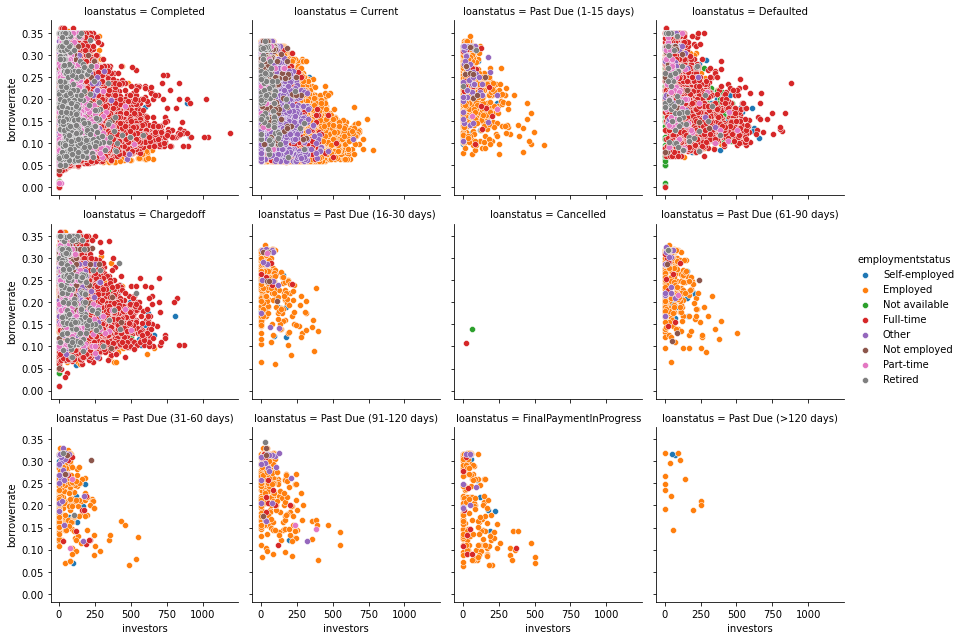